# Notes on Chapter 2: Producing your first crime map

The Caveman Coder

2026-01-18

- Spatial or environmental criminologists most often work with discrete data. In other scientific disciplines, continuous data may be more common.

Loding related packages:

```r
# packages for reading data and data carpentry
library(readr)
library(tibble)
library(janitor)
library(dplyr)
# packages for handling spatial data
library(sf)
```

```r
# packages for data visualization
library(ggplot2)
library(ggspatial)
```

Basic concepts related to spatial information: - Place: the location (like a whole country, or a particular road, etc.)  
- Attributes: any recorded characteristic or property of a place.  
- Object: model representation of a place, usually made up of points, lines, areas (polygons), or as raster data (made up of pixels or tiles) - Networks: special type of data structure used to store information that forms a graph (node-link diagram).

Important types of map in GIS: - reference map: emphasis is on the location of spatial objects like cities, mountains, rivers, etc.  
- thematic map: used to represent the spatial distribution of attributes. Also called statistical maps.

Common ideas used in dealing with geographical information: - coordinate reference system (CRS): a system of denoting every place on the Earth using numbers (aka coordinates). Can further divided into projected coordinate reference systems (rectangular or flat, or Cartesian) or geographic coordinate reference systems (uses a 3-d model like a spheroid as the “base” of reference for locating any place on Earth).

Example of a geographic coordinate system: - World Geodetic System (WGS 84): uses longitude, latitude, and elevations.

Example of a projected coordinate system: - British National Grid (BNG): uses “Easting” and “Northing”

All projections suffer from distortions because it is impossible to fit a 3-d object into a flat object.

The “EPSG” notation is usually used to refer to different coordinate systems. This notation is developed by the European Petroleum Survey Group, hence the name.

- Note: due to plate tectonics motion and maybe, other factors, objects may not line up properly even when two or more “maps” using the same coordinate system (like WGS 84 – the most common) are layered on top of each other.

## 2.6 Getting started with crime data

Reading `.csv` data:

```r
crimes <- read_csv("data/data/2019-06-greater-manchester-street.csv")
glimpse(crimes)
```

```
## Rows: 32,058
## Columns: 12
## $ `Crime ID`              <chr> NA, "aa1cc4cb0c436f463635890bcb4ff2cba08f59925…
## $ Month                   <chr> "2019-06", "2019-06", "2019-06", "2019-06", "2…
## $ `Reported by`           <chr> "Greater Manchester Police", "Greater Manchest…
## $ `Falls within`          <chr> "Greater Manchester Police", "Greater Manchest…
## $ Longitude               <dbl> -2.464422, -2.441166, -2.444807, -2.444807, -2…
## $ Latitude                <dbl> 53.61250, 53.61604, 53.61151, 53.61151, 53.606…
## $ Location                <chr> "On or near Parking Area", "On or near Pitcomb…
## $ `LSOA code`             <chr> "E01004768", "E01004768", "E01004768", "E01004…
## $ `LSOA name`             <chr> "Bolton 001A", "Bolton 001A", "Bolton 001A", "…
## $ `Crime type`            <chr> "Anti-social behaviour", "Violence and sexual …
## $ `Last outcome category` <chr> NA, "Unable to prosecute suspect", "Unable to …
## $ Context                 <lgl> NA, NA, NA, NA, NA, NA, NA, NA, NA, NA, NA, NA…
```

```r
head(crimes)
```

```
## # A tibble: 6 × 12
##   `Crime ID`      Month `Reported by` `Falls within` Longitude Latitude Location
##   <chr>           <chr> <chr>         <chr>              <dbl>    <dbl> <chr>
## 1 <NA>            2019… Greater Manc… Greater Manch…     -2.46     53.6 On or n…
## 2 aa1cc4cb0c436f… 2019… Greater Manc… Greater Manch…     -2.44     53.6 On or n…
## 3 e513df6325ec20… 2019… Greater Manc… Greater Manch…     -2.44     53.6 On or n…
## 4 6ed763df57793b… 2019… Greater Manc… Greater Manch…     -2.44     53.6 On or n…
## 5 780d55b86bf1b8… 2019… Greater Manc… Greater Manch…     -2.45     53.6 On or n…
## 6 753fa25ffee11c… 2019… Greater Manc… Greater Manch…     -2.44     53.6 On or n…
## # ℹ 5 more variables: `LSOA code` <chr>, `LSOA name` <chr>, `Crime type` <chr>,
## #   `Last outcome category` <chr>, Context <lgl>
```

Using `janitor` to clean up the variable names (remove extra spaces, etc. on the column names):

```r
crimes <- clean_names(crimes)
glimpse(crimes)
```

```
## Rows: 32,058
## Columns: 12
## $ crime_id              <chr> NA, "aa1cc4cb0c436f463635890bcb4ff2cba08f599250b…
## $ month                 <chr> "2019-06", "2019-06", "2019-06", "2019-06", "201…
## $ reported_by           <chr> "Greater Manchester Police", "Greater Manchester…
## $ falls_within          <chr> "Greater Manchester Police", "Greater Manchester…
## $ longitude             <dbl> -2.464422, -2.441166, -2.444807, -2.444807, -2.4…
## $ latitude              <dbl> 53.61250, 53.61604, 53.61151, 53.61151, 53.60627…
## $ location              <chr> "On or near Parking Area", "On or near Pitcombe …
## $ lsoa_code             <chr> "E01004768", "E01004768", "E01004768", "E0100476…
## $ lsoa_name             <chr> "Bolton 001A", "Bolton 001A", "Bolton 001A", "Bo…
## $ crime_type            <chr> "Anti-social behaviour", "Violence and sexual of…
## $ last_outcome_category <chr> NA, "Unable to prosecute suspect", "Unable to pr…
## $ context               <lgl> NA, NA, NA, NA, NA, NA, NA, NA, NA, NA, NA, NA, …
```

## 2.7 From dataframes to spatial objects

```r
head(crimes, n = 2)
```

```
## # A tibble: 2 × 12
##   crime_id  month reported_by falls_within longitude latitude location lsoa_code
##   <chr>     <chr> <chr>       <chr>            <dbl>    <dbl> <chr>    <chr>
## 1 <NA>      2019… Greater Ma… Greater Man…     -2.46     53.6 On or n… E01004768
## 2 aa1cc4cb… 2019… Greater Ma… Greater Man…     -2.44     53.6 On or n… E01004768
## # ℹ 4 more variables: lsoa_name <chr>, crime_type <chr>,
## #   last_outcome_category <chr>, context <lgl>
```

- The `latitude` and `longitude` allow us put a `point` on the map.
- The `location` variable shows the place where the crime happened along a particular road.
- The `lsoa_name` column contains names for some sort of area (the Lower Layer Super Output Area).

## 2.8 The simple features framework

Creating a simple features (or sf) object from the `longitude` and `latitude` columns:

```r
crimes_sf <- st_as_sf(
  crimes,
  coords = c("longitude", "latitude"),
  crs = 4326 # crs is WGS84
)

class(crimes_sf)
```

```
## [1] "sf"         "tbl_df"     "tbl"        "data.frame"
```

## 2.9 Plotting data with ggplot2

```r
df <- crimes |>
  filter(crime_type %in% c("Robbery", "Shoplifting", "Theft from the person")) |>
  group_by(crime_type) |>
  count()

df
```

```
## # A tibble: 3 × 2
## # Groups:   crime_type [3]
##   crime_type                n
##   <chr>                 <int>
## 1 Robbery                 463
## 2 Shoplifting            1479
## 3 Theft from the person   718
```

Plotting `df`:

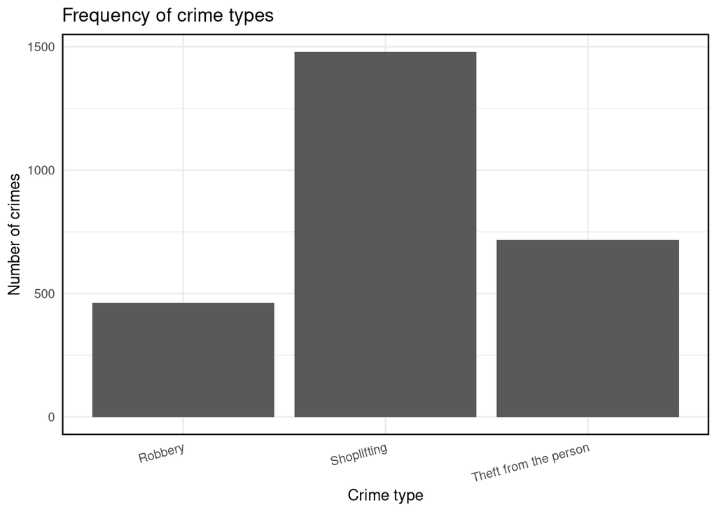

```r
ggplot(df, aes(x = crime_type, y = n)) +
  geom_col() +
  labs(title = "Frequency of crime types") +
  xlab("Crime type") +
  ylab("Number of crimes") +
  theme_minimal() +
  theme(
    axis.text.x = element_text(angle = 15, hjust = 1),
    panel.border = element_rect(color = "black", fill = NA, size = 1)
  )
```

Creating a new dataframe including `last_outcome` category variable:

```r
df2 <- crimes |>
  filter(crime_type %in% c("Robbery", "Shoplifting", "Theft from the person")) |>
  group_by(crime_type, last_outcome_category) |>
  count()

head(df2)
```

```
## # A tibble: 6 × 3
## # Groups:   crime_type, last_outcome_category [6]
##   crime_type last_outcome_category                                   n
##   <chr>      <chr>                                               <int>
## 1 Robbery    Court result unavailable                               11
## 2 Robbery    Further investigation is not in the public interest     1
## 3 Robbery    Investigation complete; no suspect identified         148
## 4 Robbery    Local resolution                                        1
## 5 Robbery    Status update unavailable                             272
## 6 Robbery    Unable to prosecute suspect                            30
```

Plotting with `fill` parameter in `aes()`:

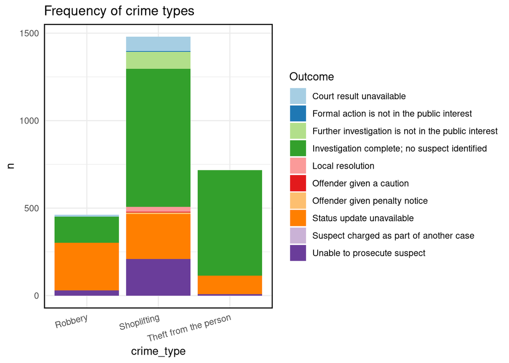

```r
df2 |> ggplot(
  aes(x = crime_type, y = n, fill = last_outcome_category)
) +
  geom_col() +
  labs(
    title = "Frequency of crime types",
    xlab = "Crime type",
    ylab = "Number of crimes"
  ) +
  theme_minimal() +
  theme(
    axis.text.x = element_text(angle = 15, hjust = 1),
    panel.border = element_rect(color = "black", fill = NA, size = 1)
  ) +
  scale_fill_brewer(
    type = "qual",
    palette = 3,
    name = "Outcome"
  )
```

## 2.10 Mapping crime data as points

Using `geom_sf` to plot spatial data in `ggplot2`:

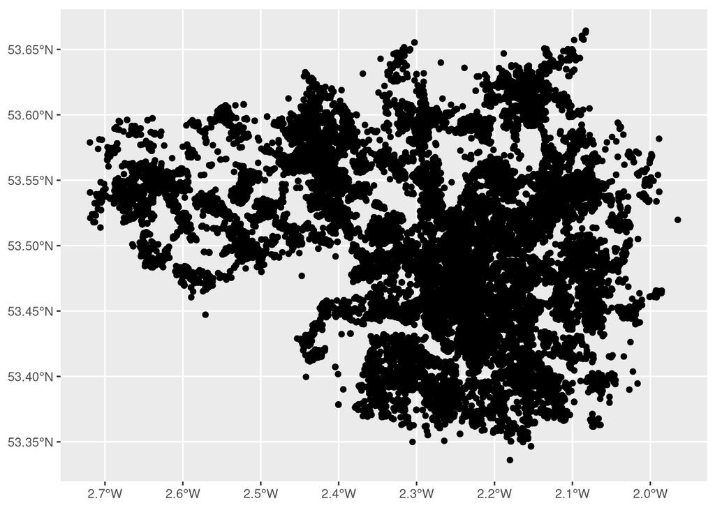

```r
crimes_sf |> ggplot() +
  geom_sf()
```

Adding abasemap layer to the plot above using `annotation_map_tile():

```
## Zoom: 9
```

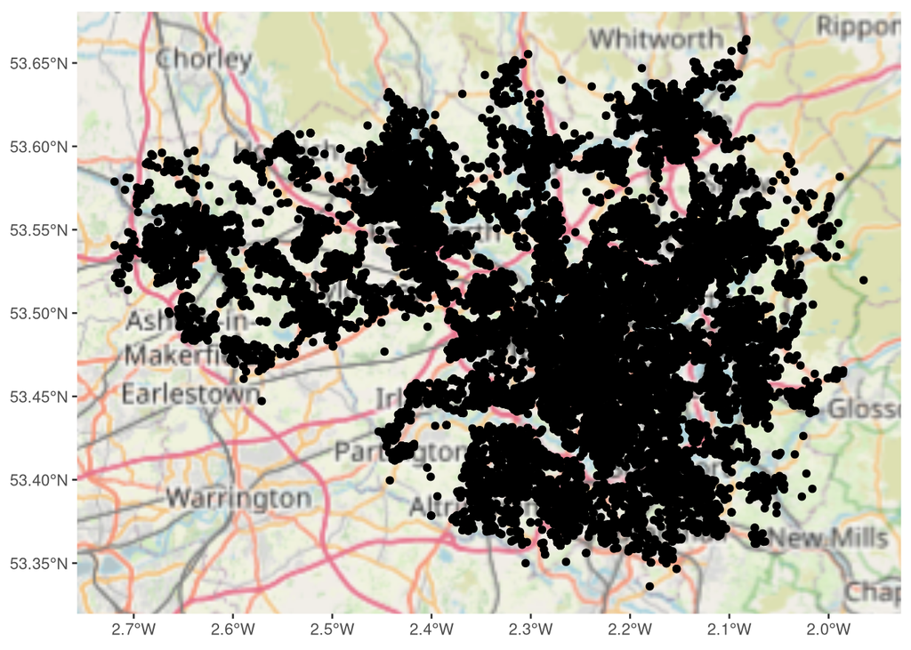

```r
crimes_sf |> ggplot() +
  annotation_map_tile() +
  geom_sf()
```

## 2.11 Mapping crime data as polygons

In this this case, more information is needed – a dataset that contains the boundaries as polygons. In the data folder, this particular dataset already exists as shapefiles.

Reading the related shapefiles using `st_read()`:

```r
shp_name <- "data/data/BoundaryData/england_lsoa_2011.shp"
manchester_lsoa <- st_read(shp_name)
glimpse(manchester_lsoa)
```

```
## Rows: 282
## Columns: 4
## $ label    <chr> "E08000003E02001062E01005066", "E08000003E02001092E01005073",…
## $ name     <chr> "Manchester 018E", "Manchester 048C", "Manchester 018A", "Man…
## $ code     <chr> "E01005066", "E01005073", "E01005061", "E01005062", "E0100506…
## $ geometry <POLYGON [m]> POLYGON ((384850 397432, 38..., POLYGON ((382221.1 38…
```

Plotting a map using shapefile data using `geom_sf()`:

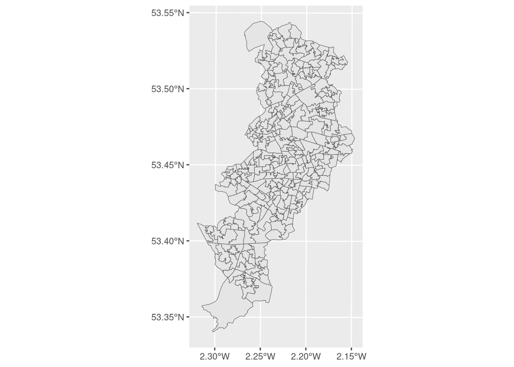

```r
manchester_lsoa |> ggplot() +
  geom_sf()
```

### Data wrangling using `dplyr` to combine crime data and the shapefile data

Checking the number of observations:

```r
nrow(manchester_lsoa)
```

```
## [1] 282
```

```r
nrow(crimes)
```

```
## [1] 32058
```

Counting the number of cases within each LSOA

```r
crimes_per_LSOA <- crimes |>
  group_by(lsoa_code) |>
  summarize(count = n())

crimes_per_LSOA
```

```
## # A tibble: 1,671 × 2
##    lsoa_code count
##    <chr>     <int>
##  1 E01004766    22
##  2 E01004767    32
##  3 E01004768     6
##  4 E01004769     9
##  5 E01004770     3
##  6 E01004771    13
##  7 E01004772    22
##  8 E01004773    16
##  9 E01004774    21
## 10 E01004775    10
## # ℹ 1,661 more rows
```

#### Joining this data to the `sf` object

Checking if the relevant datasets share a column:

```r
names(manchester_lsoa)
```

```
## [1] "label"    "name"     "code"     "geometry"
```

```r
names(crimes_per_LSOA)
```

```
## [1] "lsoa_code" "count"
```

```r
head(manchester_lsoa)
```

```
## Simple feature collection with 6 features and 3 fields
## Geometry type: POLYGON
## Dimension:     XY
## Bounding box:  xmin: 381453.3 ymin: 387925 xmax: 386933 ymax: 397654.3
## Projected CRS: OSGB36 / British National Grid
##                         label            name      code
## 1 E08000003E02001062E01005066 Manchester 018E E01005066
## 2 E08000003E02001092E01005073 Manchester 048C E01005073
## 3 E08000003E02001062E01005061 Manchester 018A E01005061
## 4 E08000003E02001062E01005062 Manchester 018B E01005062
## 5 E08000003E02001062E01005063 Manchester 018C E01005063
## 6 E08000003E02001062E01005065 Manchester 018D E01005065
##                         geometry
## 1 POLYGON ((384850 397432, 38...
## 2 POLYGON ((382221.1 388869.2...
## 3 POLYGON ((386745.9 397293.4...
## 4 POLYGON ((384601 397195, 38...
## 5 POLYGON ((386141 396808.8, ...
## 6 POLYGON ((385738 397442, 38...
```

```r
head(crimes_per_LSOA)
```

```
## # A tibble: 6 × 2
##   lsoa_code count
##   <chr>     <int>
## 1 E01004766    22
## 2 E01004767    32
## 3 E01004768     6
## 4 E01004769     9
## 5 E01004770     3
## 6 E01004771    13
```

The `code` column in `manchester_lsoa` and the `lsoa_code` column in `crime_per_lsoa` have matching values!

Joining the two datasets by these matching columns:

```r
manchester_lsoa <- left_join(
  manchester_lsoa, crimes_per_LSOA,
  by = c("code" = "lsoa_code")
)

head(manchester_lsoa)
```

```
## Simple feature collection with 6 features and 4 fields
## Geometry type: POLYGON
## Dimension:     XY
## Bounding box:  xmin: 381453.3 ymin: 387925 xmax: 386933 ymax: 397654.3
## Projected CRS: OSGB36 / British National Grid
##                         label            name      code count
## 1 E08000003E02001062E01005066 Manchester 018E E01005066    11
## 2 E08000003E02001092E01005073 Manchester 048C E01005073     9
## 3 E08000003E02001062E01005061 Manchester 018A E01005061    38
## 4 E08000003E02001062E01005062 Manchester 018B E01005062    90
## 5 E08000003E02001062E01005063 Manchester 018C E01005063    19
## 6 E08000003E02001062E01005065 Manchester 018D E01005065    56
##                         geometry
## 1 POLYGON ((384850 397432, 38...
## 2 POLYGON ((382221.1 388869.2...
## 3 POLYGON ((386745.9 397293.4...
## 4 POLYGON ((384601 397195, 38...
## 5 POLYGON ((386141 396808.8, ...
## 6 POLYGON ((385738 397442, 38...
```

Saving the result locally as a shapefile using `st_write()`:

```r
st_write(
  manchester_lsoa,
  "data/data/BoundaryData/manchester_crime_lsoa.shp",
  append = FALSE
)
```

Putting polygon data on the map:

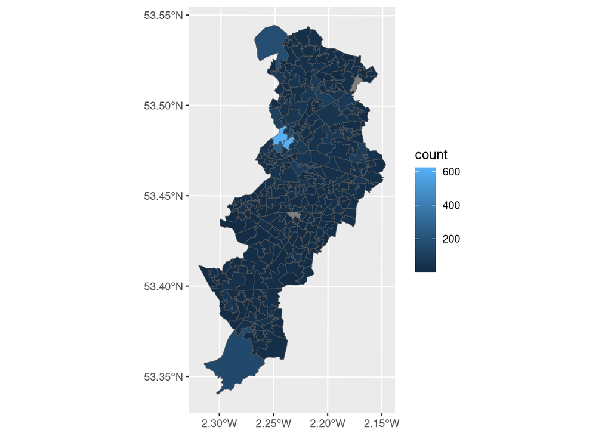

```r
manchester_lsoa |>
  ggplot() +
  geom_sf(
    aes(fill = count)
  )
```

Plotting polygon data including a basemap layer:

```
## Zoom: 10
```

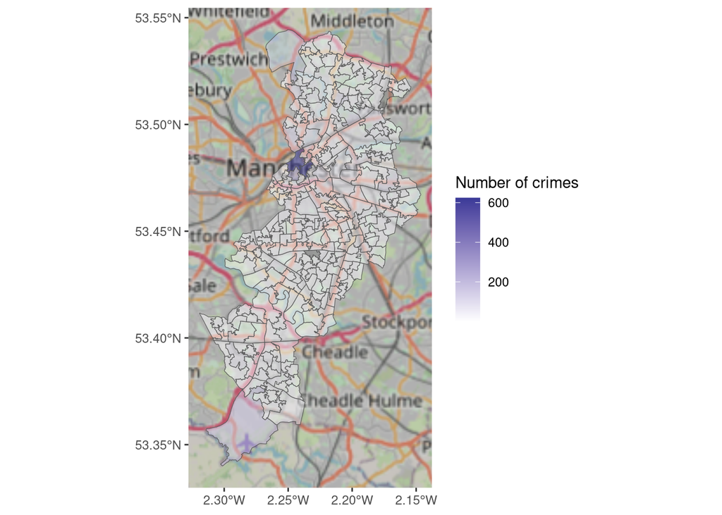

```r
manchester_lsoa |>
  ggplot() +
  # Basemap Layer
  annotation_map_tile() +
  # Polygon layer
  geom_sf(
    aes(fill = count),
    alpha = 0.5
  ) +
  scale_fill_gradient2(name = "Number of crimes")
```